# COPUS Analysis for publication

Tony Hui

# Processing the data

```r
require(knitr)
opts_chunk$set(echo=F)
```

## Sanity check the data

```
## [1] "Number of Columns for all files: 31"
```

Remove classes that are shorter than 43 minutes and longer than 51 minutes

| x | freq |
| --- | --- |
| 16 | 1 |
| 17 | 2 |
| 18 | 1 |
| 19 | 3 |
| 20 | 2 |
| 21 | 2 |
| 22 | 4 |
| 23 | 17 |
| 24 | 22 |
| 25 | 13 |
| 27 | 1 |
| 33 | 1 |
| 34 | 3 |
| 35 | 2 |
| 36 | 3 |
| 37 | 3 |
| 38 | 2 |
| 39 | 6 |
| 40 | 2 |

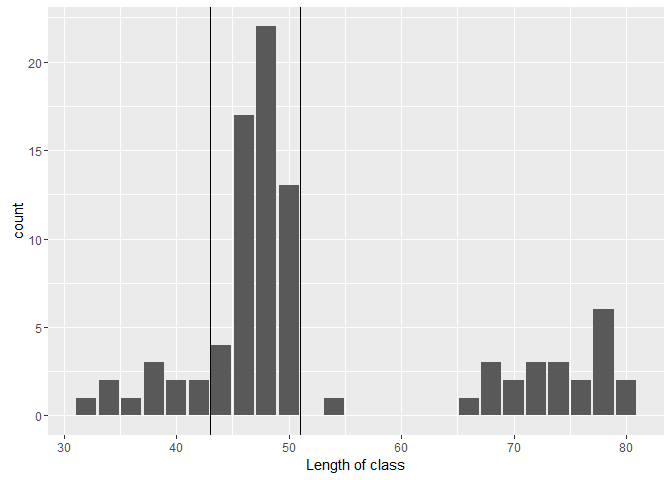

## Combine data from all classes/observations into one file

### Filter out unwanted variables

Notes from Megan: The 8 variables used in the Lund et al paper (and their short form codes from Lund’s Table 4) are:

- Student-AnsweringQuestion (AnQ-S)
- Student-AskingQuestion (SQ)
- Instructor-AskingClickerQuestion (CQ)
- Instructor-GivingFeedback (FUp)
- Instructor-Lecturing (Lec)
- Instructor-WritingOnBoard (RtW)
- Instructor-MovingThroughGroup (MG)
- Students-GroupWork (GW)
  - this is an amalgam of the three student groupwork codes, which we need to process. It is considered checked off (“1”) if any of the three student groupwork raw codes occurs in the given interval. (Students-ClickerQuestionInGroups. Students-Worksheet, Students-OtherGroupwork)

| time | course | instructor | semester | observation | year | Student.AnsweringQuestion | Student.AskingQuestion | Instructor.AskingClickerQuestion | Instructor.GivingFeedback | Instructor.Lecturing | Instructor.WritingOnBoard | Instructor.MovingThroughGroup | Students.GroupWork |
| --- | --- | --- | --- | --- | --- | --- | --- | --- | --- | --- | --- | --- | --- |
| 2 | 11 | A | 1 | 1 | 1 | 0 | 0 | 1 | 1 | 0 | 0 | 0 | 1 |
| 4 | 11 | A | 1 | 1 | 1 | 0 | 0 | 0 | 0 | 0 | 0 | 0 | 1 |
| 6 | 11 | A | 1 | 1 | 1 | 0 | 0 | 1 | 1 | 1 | 0 | 0 | 1 |
| 8 | 11 | A | 1 | 1 | 1 | 0 | 0 | 1 | 1 | 0 | 0 | 0 | 1 |
| 10 | 11 | A | 1 | 1 | 1 | 0 | 1 | 0 | 1 | 0 | 0 | 0 | 0 |
| 12 | 11 | A | 1 | 1 | 1 | 0 | 0 | 0 | 1 | 0 | 0 | 0 | 1 |

## Process the class performance data

| course | instructor | semester | EffectSize.StudentPerformance | SE.EffectSize.StudentPerformance | ClassSize | CopusProfile | CopusStyle | TeachingPracticesInventoryScore | NormalizedChange.StudentPerformance | SE.NormalizedChange.StudentPerformance |
| --- | --- | --- | --- | --- | --- | --- | --- | --- | --- | --- |
| 11 | A | 1 | 2.91 | 0.17 | More than 200 | Student-Centered Peer Instruction | Collaborative | 20 | 74.09648 | 1.853726 |
| 11 | B | 1 | 1.51 | 0.16 | More than 200 | Limited Peer Instruction (with slides) | Peer Instruction | 20 | 56.49132 | 3.643105 |
| 11 | C | 1 | 2.65 | 0.15 | More than 200 | Student-Centered Peer Instruction | Collaborative | 20 | 70.73516 | 2.167993 |
| 11 | D | 1 | 2.75 | 0.16 | More than 200 | Student-Centered Peer Instruction | Collaborative | 20 | 69.68558 | 1.855365 |
| 12 | E | 2 | 1.36 | 0.21 | More than 200 | Teacher-Centered Peer Instruction | Peer Instruction | 16 | 29.07547 | 3.354000 |
| 12 | H | 2 | 1.05 | 0.18 | More than 200 | Student-Centered Peer Instruction | Collaborative | 17 | 22.28033 | 3.297568 |

### Merge performance data with the classes data

# Basic exploratory analysis

## Fractional amount of time spent on each category overall per class

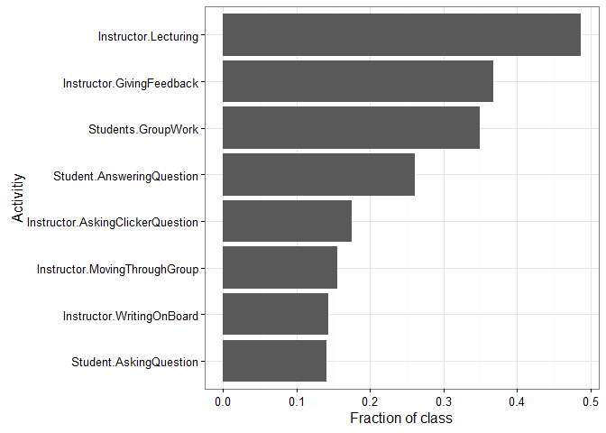

## Fractional amount of time spent on each category overall per class year

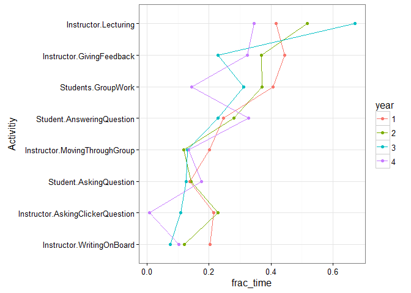

## Number of different instructor-semester pairings per per course

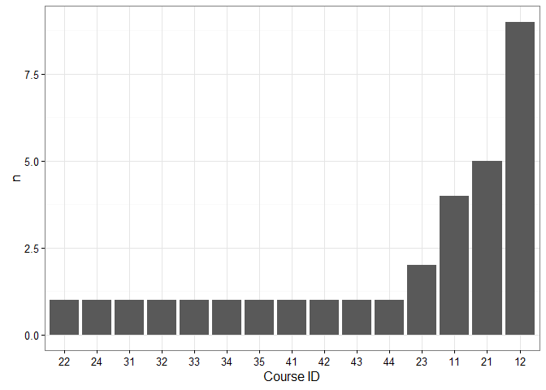

## Fractional amount of time spent on each category for course `12`, `21`, and `11`, further granuarized by instructor

The labels in each box represents the course id

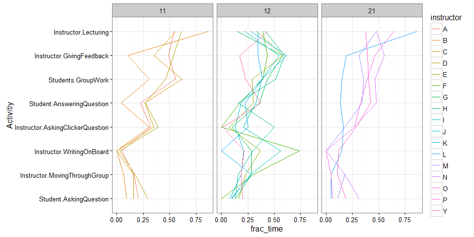

## Time spent on lecture vs student growth

All courses - each dot is one course (separated by year level)

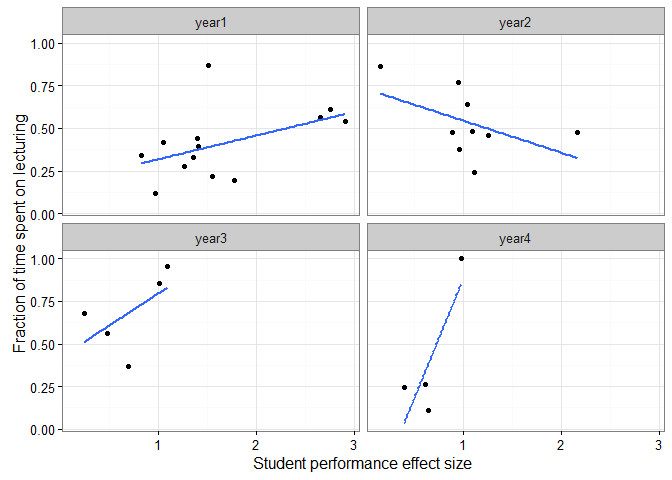

Looks like there’s a positive correlation with lecture time and student performance in first year classes, and a negative correlation in second year classes